# Sales Analysis

### Import Necessary Libraries

```python
import pandas as pd
import os
import numpy as np
import matplotlib.pyplot as plt
from wordcloud import WordCloud
```

### Task 1: Merging 12 months of sales into a single file

```python
# Tugasnya adalah menjadikan 12 file .csv menjadi sebuah file .csv dengan menggunakan dataframe
#df = pd.read_csv("./Sales_Data/Sales_April_2019.csv")

files = [file for file in os.listdir('./Sales_Data')]

all_months_data = pd.DataFrame()

for file in files:
    df = pd.read_csv("./Sales_Data/"+file)
    all_months_data = pd.concat([all_months_data, df])

# all_months_data.head()
# all_months_data.to_csv("all_data.csv", index=False)
```

### Read in update dataframe

```python
all_data = pd.read_csv("all_data.csv")
all_data.head()
```

|  | Order ID | Product | Quantity Ordered | Price Each | Order Date | Purchase Address |
| --- | --- | --- | --- | --- | --- | --- |
| 0 | 176558 | USB-C Charging Cable | 2 | 11.95 | 04/19/19 08:46 | 917 1st St, Dallas, TX 75001 |
| 1 | 176559 | Bose SoundSport Headphones | 1 | 99.99 | 04/07/19 22:30 | 682 Chestnut St, Boston, MA 02215 |
| 2 | 176560 | Google Phone | 1 | 600 | 04/12/19 14:38 | 669 Spruce St, Los Angeles, CA 90001 |
| 3 | 176560 | Wired Headphones | 1 | 11.99 | 04/12/19 14:38 | 669 Spruce St, Los Angeles, CA 90001 |
| 4 | 176561 | Wired Headphones | 1 | 11.99 | 04/30/19 09:27 | 333 8th St, Los Angeles, CA 90001 |

### Clean up the data! There're NaN data

#### Drop rows of NAN

```python
nan_df = all_data[all_data.isna().any(axis=1)]
#nan_df.head()
all_data = all_data.dropna(how='all')
all_data.head()
```

|  | Order ID | Product | Quantity Ordered | Price Each | Order Date | Purchase Address |
| --- | --- | --- | --- | --- | --- | --- |
| 0 | 176558 | USB-C Charging Cable | 2 | 11.95 | 04/19/19 08:46 | 917 1st St, Dallas, TX 75001 |
| 1 | 176559 | Bose SoundSport Headphones | 1 | 99.99 | 04/07/19 22:30 | 682 Chestnut St, Boston, MA 02215 |
| 2 | 176560 | Google Phone | 1 | 600 | 04/12/19 14:38 | 669 Spruce St, Los Angeles, CA 90001 |
| 3 | 176560 | Wired Headphones | 1 | 11.99 | 04/12/19 14:38 | 669 Spruce St, Los Angeles, CA 90001 |
| 4 | 176561 | Wired Headphones | 1 | 11.99 | 04/30/19 09:27 | 333 8th St, Los Angeles, CA 90001 |

#### Find 'Or' and delete it

```python
all_data = all_data[all_data['Order Date'].str[0:2] != 'Or']
```

#### Convert columns to the correct type(from str to int)

```python
all_data['Quantity Ordered'] = pd.to_numeric(all_data['Quantity Ordered']) # Make int
all_data['Price Each'] = pd.to_numeric(all_data['Price Each']) # Make float

#all_data.head()
```

### Augment data with additional columns

#### Task 2: Add Month Column

```python
#we don't have moth column, instead we have date column. Also we're going to convert Order Date into string

all_data['Month'] = all_data['Order Date'].str[0:2] # 2 means first 2 characters
all_data['Month'] = all_data['Month'].astype('int32')
all_data.head()
```

|  | Order ID | Product | Quantity Ordered | Price Each | Order Date | Purchase Address | Month |
| --- | --- | --- | --- | --- | --- | --- | --- |
| 0 | 176558 | USB-C Charging Cable | 2 | 11.95 | 04/19/19 08:46 | 917 1st St, Dallas, TX 75001 | 4 |
| 1 | 176559 | Bose SoundSport Headphones | 1 | 99.99 | 04/07/19 22:30 | 682 Chestnut St, Boston, MA 02215 | 4 |
| 2 | 176560 | Google Phone | 1 | 600.00 | 04/12/19 14:38 | 669 Spruce St, Los Angeles, CA 90001 | 4 |
| 3 | 176560 | Wired Headphones | 1 | 11.99 | 04/12/19 14:38 | 669 Spruce St, Los Angeles, CA 90001 | 4 |
| 4 | 176561 | Wired Headphones | 1 | 11.99 | 04/30/19 09:27 | 333 8th St, Los Angeles, CA 90001 | 4 |

#### Tasl 3: Add a sales column

##### Karena di tabel hanya ada jumlah order(Quantity Ordered) dan Price Each maka akan dilakukan pengalian

```python
all_data['Sales'] = all_data['Quantity Ordered'] * all_data['Price Each']
all_data.head()
```

|  | Order ID | Product | Quantity Ordered | Price Each | Order Date | Purchase Address | Month | Sales |
| --- | --- | --- | --- | --- | --- | --- | --- | --- |
| 0 | 176558 | USB-C Charging Cable | 2 | 11.95 | 04/19/19 08:46 | 917 1st St, Dallas, TX 75001 | 4 | 23.90 |
| 1 | 176559 | Bose SoundSport Headphones | 1 | 99.99 | 04/07/19 22:30 | 682 Chestnut St, Boston, MA 02215 | 4 | 99.99 |
| 2 | 176560 | Google Phone | 1 | 600.00 | 04/12/19 14:38 | 669 Spruce St, Los Angeles, CA 90001 | 4 | 600.00 |
| 3 | 176560 | Wired Headphones | 1 | 11.99 | 04/12/19 14:38 | 669 Spruce St, Los Angeles, CA 90001 | 4 | 11.99 |
| 4 | 176561 | Wired Headphones | 1 | 11.99 | 04/30/19 09:27 | 333 8th St, Los Angeles, CA 90001 | 4 | 11.99 |

#### Task 4: Add a city column

```python
def get_city(address):
    return address.split(',')[1]

def get_state(address):
    return address.split(',')[2].split(' ')[1]

#all_data['City'] = all_data['Purchase Address'].apply(lambda x: get_city(x) + '( ' + get_state(x) + ')') atau
all_data['City'] = all_data['Purchase Address'].apply(lambda x: f"{get_city(x)} ({get_state(x)})")

#Lambda x means the x value here is the cell content.
#So we're saying for each of these cell contents we want to split it by commas and then grab the first index.
# kalau mw drop {all_data = all_data.drop(columns='nama kolom')}

all_data.head()
```

|  | Order ID | Product | Quantity Ordered | Price Each | Order Date | Purchase Address | Month | Sales | City |
| --- | --- | --- | --- | --- | --- | --- | --- | --- | --- |
| 0 | 176558 | USB-C Charging Cable | 2 | 11.95 | 04/19/19 08:46 | 917 1st St, Dallas, TX 75001 | 4 | 23.90 | Dallas (TX) |
| 1 | 176559 | Bose SoundSport Headphones | 1 | 99.99 | 04/07/19 22:30 | 682 Chestnut St, Boston, MA 02215 | 4 | 99.99 | Boston (MA) |
| 2 | 176560 | Google Phone | 1 | 600.00 | 04/12/19 14:38 | 669 Spruce St, Los Angeles, CA 90001 | 4 | 600.00 | Los Angeles (CA) |
| 3 | 176560 | Wired Headphones | 1 | 11.99 | 04/12/19 14:38 | 669 Spruce St, Los Angeles, CA 90001 | 4 | 11.99 | Los Angeles (CA) |
| 4 | 176561 | Wired Headphones | 1 | 11.99 | 04/30/19 09:27 | 333 8th St, Los Angeles, CA 90001 | 4 | 11.99 | Los Angeles (CA) |

### Question 1: What was the best month for sales? How much was earned that month?

```python
results = all_data.groupby('Month').sum()[['Quantity Ordered','Sales']]
# spesific
results.head(12)
```

| Month | Quantity Ordered | Sales |
| --- | --- | --- |
| 1 | 10903 | 1.822257e+06 |
| 2 | 13449 | 2.202022e+06 |
| 3 | 17005 | 2.807100e+06 |
| 4 | 20558 | 3.390670e+06 |
| 5 | 18667 | 3.152607e+06 |
| 6 | 15253 | 2.577802e+06 |
| 7 | 16072 | 2.647776e+06 |
| 8 | 13448 | 2.244468e+06 |
| 9 | 13109 | 2.097560e+06 |
| 10 | 22703 | 3.736727e+06 |
| 11 | 19798 | 3.199603e+06 |
| 12 | 28114 | 4.613443e+06 |

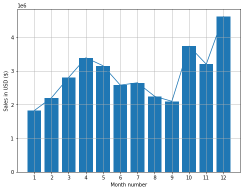

```python
months = range(1,13)
#<=1 & <13

plt.bar(months, results['Sales'])
plt.xticks(months)

line = all_data.groupby(["Month"])["Sales"].sum().round(2)
line.plot(kind="line", x="Month", y="Sales", figsize=(8,6))
plt.grid()

plt.ylabel('Sales in USD ($)')
plt.xlabel('Month number')
plt.show()
```

### Question 2: What city had the highest number of sales

```python
results = all_data.groupby('City').sum()
results
```

| City | Quantity Ordered | Price Each | Month | Sales |
| --- | --- | --- | --- | --- |
| Atlanta (GA) | 16602 | 2.779908e+06 | 104794 | 2.795499e+06 |
| Austin (TX) | 11153 | 1.809874e+06 | 69829 | 1.819582e+06 |
| Boston (MA) | 22528 | 3.637410e+06 | 141112 | 3.661642e+06 |
| Dallas (TX) | 16730 | 2.752628e+06 | 104620 | 2.767975e+06 |
| Los Angeles (CA) | 33289 | 5.421435e+06 | 208325 | 5.452571e+06 |
| New York City (NY) | 27932 | 4.635371e+06 | 175741 | 4.664317e+06 |
| Portland (ME) | 2750 | 4.471893e+05 | 17144 | 4.497583e+05 |
| Portland (OR) | 11303 | 1.860558e+06 | 70621 | 1.870732e+06 |
| San Francisco (CA) | 50239 | 8.211462e+06 | 315520 | 8.262204e+06 |
| Seattle (WA) | 16553 | 2.733296e+06 | 104941 | 2.747755e+06 |

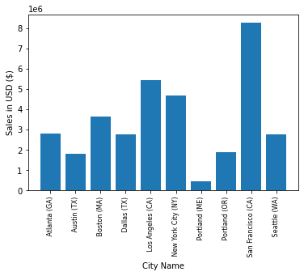

```python
import matplotlib.pyplot as plt

cities = [city for city, df in all_data.groupby('City')]

plt.bar(cities, results['Sales'])
plt.xticks(cities, rotation = 'vertical', size = 8)
plt.ylabel('Sales in USD ($)')
plt.xlabel('City Name')
plt.show()
```

### Question 3: What time should we display advertisements to maximize likelihood of customer's buying product?

```python
all_data['Order Date'] = pd.to_datetime(all_data['Order Date'])
```

```python
all_data['Hour'] = all_data['Order Date'].dt.hour
all_data['Minute'] = all_data['Order Date'].dt.minute
all_data.head()
```

|  | Order ID | Product | Quantity Ordered | Price Each | Order Date | Purchase Address | Month | Sales | City | Hour | Minute |
| --- | --- | --- | --- | --- | --- | --- | --- | --- | --- | --- | --- |
| 0 | 176558 | USB-C Charging Cable | 2 | 11.95 | 2019-04-19 08:46:00 | 917 1st St, Dallas, TX 75001 | 4 | 23.90 | Dallas (TX) | 8 | 46 |
| 1 | 176559 | Bose SoundSport Headphones | 1 | 99.99 | 2019-04-07 22:30:00 | 682 Chestnut St, Boston, MA 02215 | 4 | 99.99 | Boston (MA) | 22 | 30 |
| 2 | 176560 | Google Phone | 1 | 600.00 | 2019-04-12 14:38:00 | 669 Spruce St, Los Angeles, CA 90001 | 4 | 600.00 | Los Angeles (CA) | 14 | 38 |
| 3 | 176560 | Wired Headphones | 1 | 11.99 | 2019-04-12 14:38:00 | 669 Spruce St, Los Angeles, CA 90001 | 4 | 11.99 | Los Angeles (CA) | 14 | 38 |
| 4 | 176561 | Wired Headphones | 1 | 11.99 | 2019-04-30 09:27:00 | 333 8th St, Los Angeles, CA 90001 | 4 | 11.99 | Los Angeles (CA) | 9 | 27 |

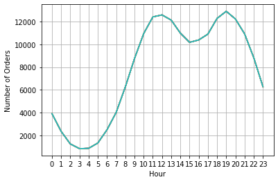

```python
hours = [hour for hour, df in all_data.groupby('Hour')]

plt.plot(hours, all_data.groupby(['Hour']).count())

plt.xlabel('Hour')
plt.ylabel('Number of Orders')
plt.xticks(hours)
plt.grid()
plt.show()
```

Visualization of plot chart shows that the average of visitors are:

- Peaks at around 11am and another peak at 7pm. Kinda make sense, maybe 11am is a lunch time and 7pm after work
- If we gonna advertise effectively, I would say right before 11am or 6pm. Would be a good time of the peaks when all the orders in our data set happened

My recommendation is around 11am (11) or 7pm (19)

### Question 4: What products are most often sold together?

```python
#if they've the same order ID, that means those products are sold in a same time

#first we want to know all the spots in data frame
df = all_data[all_data['Order ID'].duplicated(keep=False)]
# click false and Shift+Tab, you will know the cuntion. Keep is basically is to keep all duplicate
# now we're going to group it together

df['Grouped'] = df.groupby('Order ID')['Product'].transform(lambda x: ','.join(x))

df = df[['Order ID', 'Grouped']].drop_duplicates()

df.head()
```

|  | Order ID | Grouped |
| --- | --- | --- |
| 2 | 176560 | Google Phone,Wired Headphones |
| 17 | 176574 | Google Phone,USB-C Charging Cable |
| 29 | 176585 | Bose SoundSport Headphones,Bose SoundSport Hea... |
| 31 | 176586 | AAA Batteries (4-pack),Google Phone |
| 118 | 176672 | Lightning Charging Cable,USB-C Charging Cable |

```python
# we need to count the pairs

# Referenced: https://stackoverflow.com/question/52195887/counting-unique-pairs-of-numbers-into-a-python-dictionary
from itertools import combinations
from collections import Counter

count = Counter()

for row in df['Grouped']:
    row_list = row.split(',')
    count.update(Counter(combinations(row_list, 2)))

#count.most_common(10)
for key, value in count.most_common(10):
    print(key, value)
```

```
('iPhone', 'Lightning Charging Cable') 1005
('Google Phone', 'USB-C Charging Cable') 987
('iPhone', 'Wired Headphones') 447
('Google Phone', 'Wired Headphones') 414
('Vareebadd Phone', 'USB-C Charging Cable') 361
('iPhone', 'Apple Airpods Headphones') 360
('Google Phone', 'Bose SoundSport Headphones') 220
('USB-C Charging Cable', 'Wired Headphones') 160
('Vareebadd Phone', 'Wired Headphones') 143
('Lightning Charging Cable', 'Wired Headphones') 92
```

in this part, I didn't do any visualization. Instead i use list to provide data, I think by combining data and count all the data are hard to make into a visualization.

### Question 5: What product sold the most? Why do you think it sold the most?

```python
all_data.head()
```

|  | Order ID | Product | Quantity Ordered | Price Each | Order Date | Purchase Address | Month | Sales | City | Hour | Minute |
| --- | --- | --- | --- | --- | --- | --- | --- | --- | --- | --- | --- |
| 0 | 176558 | USB-C Charging Cable | 2 | 11.95 | 2019-04-19 08:46:00 | 917 1st St, Dallas, TX 75001 | 4 | 23.90 | Dallas (TX) | 8 | 46 |
| 1 | 176559 | Bose SoundSport Headphones | 1 | 99.99 | 2019-04-07 22:30:00 | 682 Chestnut St, Boston, MA 02215 | 4 | 99.99 | Boston (MA) | 22 | 30 |
| 2 | 176560 | Google Phone | 1 | 600.00 | 2019-04-12 14:38:00 | 669 Spruce St, Los Angeles, CA 90001 | 4 | 600.00 | Los Angeles (CA) | 14 | 38 |
| 3 | 176560 | Wired Headphones | 1 | 11.99 | 2019-04-12 14:38:00 | 669 Spruce St, Los Angeles, CA 90001 | 4 | 11.99 | Los Angeles (CA) | 14 | 38 |
| 4 | 176561 | Wired Headphones | 1 | 11.99 | 2019-04-30 09:27:00 | 333 8th St, Los Angeles, CA 90001 | 4 | 11.99 | Los Angeles (CA) | 9 | 27 |

```python
df_sales = all_data.groupby('Product').sum()[['Quantity Ordered','Sales']]
df_sales.sort_values(by=['Sales'],ascending=False).head()
#Items that are sold with highest sales
```

| Product | Quantity Ordered | Sales |
| --- | --- | --- |
| Macbook Pro Laptop | 4728 | 8037600.00 |
| iPhone | 6849 | 4794300.00 |
| ThinkPad Laptop | 4130 | 4129958.70 |
| Google Phone | 5532 | 3319200.00 |
| 27in 4K Gaming Monitor | 6244 | 2435097.56 |

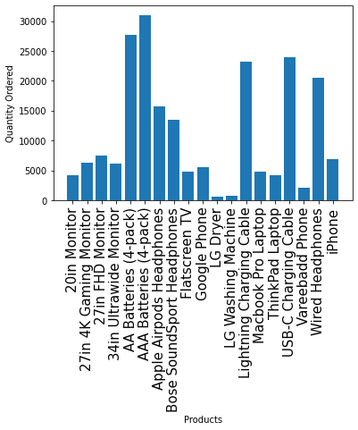

```python
product_group = all_data.groupby('Product')
quantity_ordered = product_group.sum()['Quantity Ordered']

products = [product for product, df in product_group]

plt.bar(products, quantity_ordered)
plt.ylabel('Quantity Ordered')
plt.xlabel('Products')
plt.xticks(products, rotation='vertical', size=15)
plt.show()

# My hypothesis, those items are cheap
```

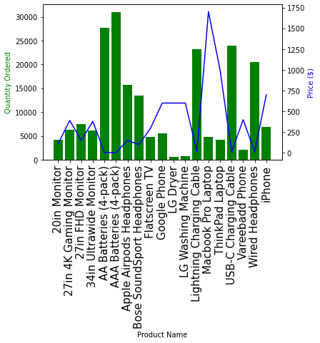

```python
prices = all_data.groupby('Product').mean()['Price Each']

fig, ax1 = plt.subplots()
ax2 = ax1.twinx()
ax1.bar(products, quantity_ordered, color = 'g')
ax2.plot(products, prices, 'b-')

ax1.set_xlabel('Product Name')
ax1.set_ylabel('Quantity Ordered', color='g')
ax2.set_ylabel('Price ($)', color='b')
ax1.set_xticklabels(products, rotation='vertical', size=15)

plt.show()
```

### WordCloud of Sales Product

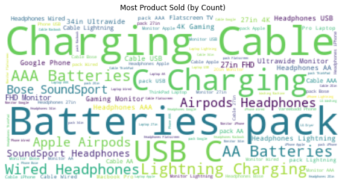

```python
wordcloud = WordCloud(max_font_size=50, max_words=100, background_color="white").generate(' '.join(all_data['Product']))
plt.figure(figsize=(10,8))
plt.imshow(wordcloud, interpolation="bilinear")
plt.axis("off")
plt.title('Most Product Sold (by Count)')
plt.show()
```